# 00 Flexdashboard Walkthrough

[figure not shown]

## Why Dashboards?

- Dashboards create an easy way to interpret and report data to others.
  - Key performance indicators
  - Data visualizations
  - Exploring Data
- Interactive Dashboards allow users to manipulate the data that is used in the visualizations

## Flexdashboard

- **flexdashboard** is an R package that allows you to easily build dashboards using *Rmarkdown*.
- Utilize *shiny* functions in a simple template dashboard to create interactive dashboards.

## Example Dashboards

[Google Trends Dashboard for Marketing Lab](https://byumarketinglab.shinyapps.io/gtrends_dashboard/)

[Book of Mormon Sentiment Analysis](https://zwix14.shinyapps.io/bom_dashboard/)

## Sketch out what you want

With dashboards it is best to figure out what kind of layout you want, the type of visuals or data you want to include.

Keeping things simple is best when telling a story with any data, especially to people who aren’t data savvy.

## Workflow

1. Import Data packages
2. Determine what analysis you want to include (graphs, tables, value boxes etc.)
3. Define inputs (if you are creating an interactive dashboard)
4. Create visualizations
5. Layout

## Set up

1. Open a new document in R
2. Choose drop down and select Rmarkdown
3. Choose “From Template”
4. Select “flexdashboard”

## Elements of flexdashboard

- yaml header
- Layout (columns or rows)
- Code chunks
- Charts
- Sidebar

## YAML Header

- There are many different types of outputs that Rmarkdown allows you to **knit** to a type of file:
- `word_document`
- `html_document`
- `github_document`

flexdashboard introduces a more complex output that influences the dashboard layout. Here is an example of what you might put in the yaml if you wanted to create a dashboard oriented by row and with a *scroll* layout.

`flexdashboard::flex_dashboard:`

`orientation: rows`

`vertical_layout: scroll`

- Additionally use this in the yaml to utilize *shiny* functions:

`runtime: shiny`

yaml headers can become very complex but there are many useful things to add.

Such as adding a theme to your dashboard with `theme: yeti` in the output parameters.

[List of themes](https://rmarkdown.rstudio.com/flexdashboard/using.html#appearance)

## Layout

The yaml header influences the layout of the dashboard

- orientation is the layout of the charts which can be *columns* or *rows* (the default orientation is columns)
- vertical_layout changes how it fits the web page with *fill* or *scroll* as options
- Another element of the yaml is *theme*. Changes font, color, etc.

## Making a Column or Row

Columns and Rows are defined by the level 2 markdown header annotation:

`-----------------------`

- Code chunks following the header will show up in that column/row
- Data width or height can be modified above header annotation between {}

`{data-width=650px}`

## Code Chunks

Any code that has an output will be shown in the dashboard.

Data cleaning, manipulation, etc can be performed in the background just showing the data insights on the dashboard by assigning it to an object without printing.

Data Visuals (i.e. graphs and tables) and Rendered elements (i.e. `renderText()` and `renderValue()`) will show on the dashboard.

Chunks will be given titles by using markdown header (`###`)

Additional code chunks under the column/row header will be included in that column/row

You can also include explanatory text to go along with your dashboard like an Rmarkdown document.

## Example Images of the different layouts

## Column Orientation

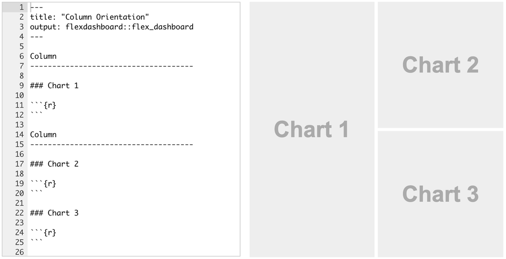

## Row Orientation

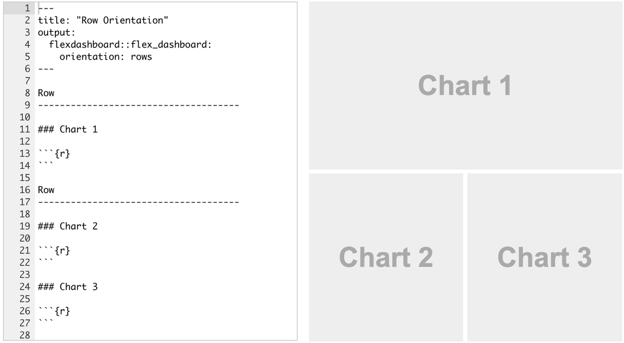

## Stack Scrolling

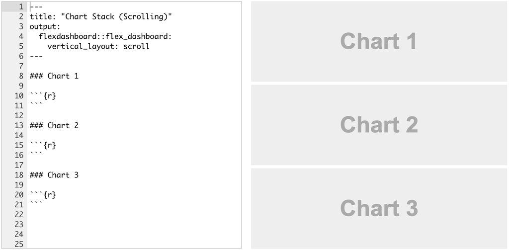

## Packages

We use the *flexdashboard* and *shiny* packages to access the functions that allow you to build interactive plots in a dashboard.

```r
# Packages
library(tidyverse)
library(flexdashboard)
library(shiny)

# Load Data
customer_data <- read_csv(here::here("data", "customer_data.csv")) %>%
   mutate(age = 2021 - birth_year)
```

## Input Sidebar

You can do this first or last but knowing what you want to influence your charts will help with creating an interactive dashboard.

Sidebars are useful for placing input fields that allow you to interact with your data visualization.

It is always on the left hand side of your dashboard and is fixed. (doesn’t scroll with the rest of dashboard)

You create an input sidebar similar to making a column/row except add the parameter of `{.sidebar}`

followed by the same markdown header as a column:

`-----------------------`

## Input Functions

Input functions allow you to make various kinds of inputs that will let you interact with your data.

There are many different input functions included in *shiny* and *flexdashboard* packages.

Components in all input functions:

- Input id
- Input label

```r
# Select Region User Input
selectInput(
  inputId = "region",
  label = "Region",
  choices = unique(customer_data[,8])     # Index Data set for Choices values
)
```

## Adding Charts

Let’s add a chart with a filter that will be influenced by the input. In order to reference a **reactive** element (the input function). We need to create a **reactive** environment using render functions.

To call an input you use `input$inputid` in our case `input$region`.

```r
renderPlot({                                # Call render function
  customer_data %>%                         # Make plot
    filter(region == input$region) %>%      # Reference Input ID
    select(age, gender:region) %>%
    ggplot(aes(x = income, fill = gender)) +
    geom_density(alpha = 0.5)
})

  # customer_data %>%                         # Make plot
  #   filter(region == "South") %>%      # Reference Input ID
  #   select(age, gender:region) %>%
  #   ggplot(aes(x = income, fill = gender)) +
  #   geom_density(alpha = 0.5)
```

## Note on Shiny functions

They will not show up in your plots tab or in the console. You must knit your document and run the dashboard before being able to see these special functions.

## Adding Value Box

Now let’s make a value boxes to call out a particular value that would be interesting.

Use the `icon =` argument to add a favicon.

Also we are rounding the number so there aren’t a lot of decimal places

```r
# Make empty reactive expression
summary <- reactive({ })


renderValueBox({                      # Call Render Function
  summary <- customer_data %>%        # Fill Reactive Expression with Summary
    filter(region == input$region)

  valueBox(                           # Call Value box Function
    round(mean(summary$income),0),
    icon = "fa-money"
  )
})
```

## Adding a table

```r
mpg_summary <- mpg %>%
  group_by(manufacturer) %>%
  summarize(
    n = n(),
    avg_hwy = mean(hwy),
    avg_cty = mean(cty)
  ) %>%
  arrange(desc(n))
```

[output not shown]

## Knitting

Transforms document into various outputs which allow you to share your files: word, github document, html, slides, etc.

Flexdashboards are different. Technically a webapp knit option may say “*run document*.”

Since it doesn’t created a knitted file you need to publish it in order to share it.

## Sharing your dashboard

1. Make shinyapps.io account
- [Sign up for a free account](https://www.shinyapps.io/admin/#/signup)
- Choose username
1. Install `rsconnect` package
- Authorize Account
1. Publishing
- Run Document > Publish
- This document > Choose shinyapps.io account
- Publish (takes a few moments)
1. Sharing
- Share url from shinyapps.io

## Wrapping Up

*Summary*

- How to open a flexdashboard template through Rmarkdown.
- How to modify the layout of the dashboard.
- Create an interactive plot using a sidebar and `selectInput()`.

*Supplementary Material*

- [Flexdashboard for R](https://rmarkdown.rstudio.com/flexdashboard/index.html)
- [Rmarkdown Basics](https://rmarkdown.rstudio.com/authoring_basics.html)

## Exercise 00

Open the exercise via the RStudio Cloud workspace and do the following.